# Notebook report

## Report for Simulation Video #3

In this report we answer the same question reviewed in [Radiant Tutorial Series: Probability Calculator Video 2](https://youtu.be/30YsxCTbDTc). To review, lets first see how to solve the question about Brita’s water filters using *Basics > Probability calculator*.

1. Since the distribution over the number of gallons before the filter signals replacement is normally distributed and governed by the historical mean and standard deviation, I selected “Normal” as the *distribution type* in the probability calculator. The mean is 100 and the standard deviation is 8.

$\pm$ 10 gallons from the mean indicates that the lower bound is 90 and the upper bound is 110. Thus the probability that a filter’s signal occurs $\pm$ 10 gallons from the mean is 0.789.

```r
result <- prob_norm(mean = 100, stdev = 8, lb = 90, ub = 110)
summary(result)
```

```
Probability calculator
Distribution: Normal
Mean        : 100
St. dev     : 8
Lower bound : 90
Upper bound : 110

P(X < 90) = 0.106
P(X > 90) = 0.894
P(X < 110) = 0.894
P(X > 110) = 0.106
P(90 < X < 110)     = 0.789
1 - P(90 < X < 110) = 0.211
```

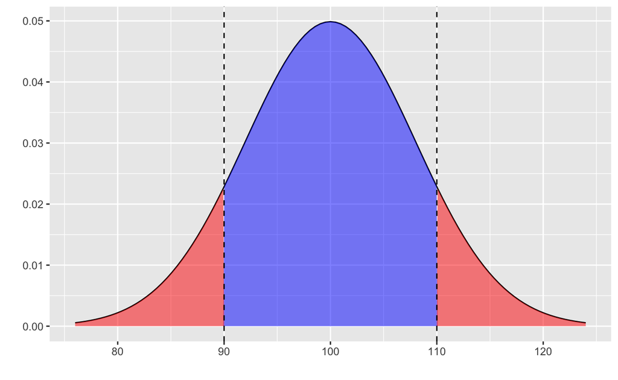

```r
plot(result)
```

2. The relenvant distribution here is the Binomial. From question (a) we know that the probability of a filter with good quality is 0.789 so I selected “Binomial” as *distribution type* in the probability calculator with $n = 5$ and $p = 0.789$. I set the lower bound as 3 and the probability that at least 3 of 5 examined filters are good is 0.933.

```r
result <- prob_binom(n = 5, p = 0.789, lb = 3)
summary(result)
```

```
Probability calculator
Distribution: Binomial
n           : 5
p           : 0.789
Mean        : 3.945
St. dev     : 0.912
Lower bound : 3
Upper bound :

P(X  = 3) = 0.219
P(X  < 3) = 0.067
P(X <= 3) = 0.285
P(X  > 3) = 0.714
P(X >= 3) = 0.933
```

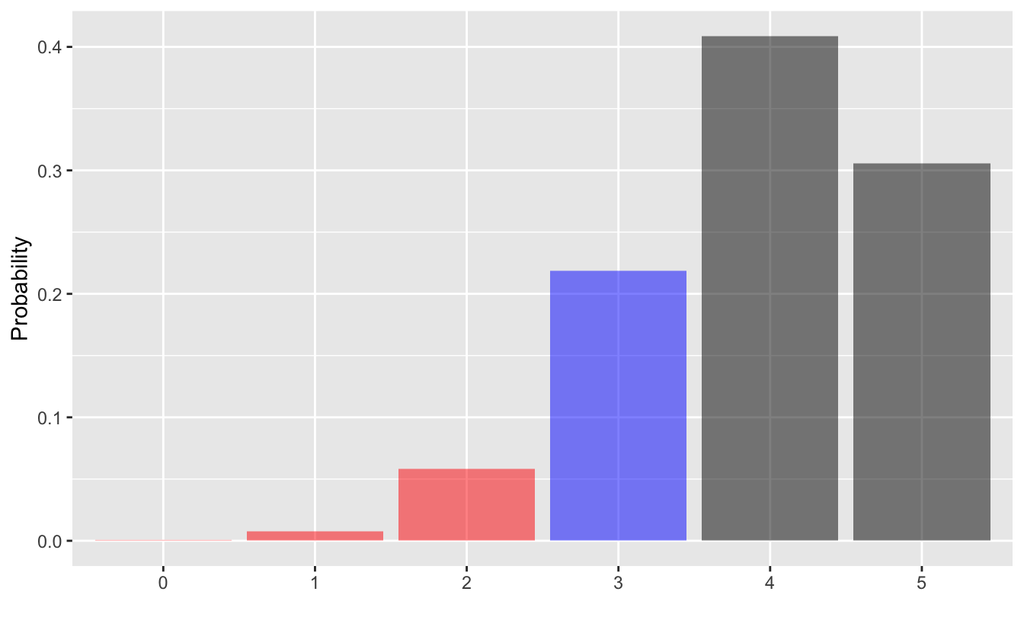

```r
plot(result)
```

We will now solve the same questions using the simulation tool in Radiant. I chose Normal distribution in the *Model > Simulate* tab. For the normal distribution, lets choose the variable name “brita” with mean of 100 gallons and standard deviation of 8 gallons. I specified the simulation formula as $good\_quality = (brita > 90)\ \&\ (brita < 110)$. I set the random seed to 1234 and ran 5,000 simulations. The simulated data was saved in the dataset *simdat*.

The simulation summary below shows that the probability that a filter’s signal occurs ±10 gallons from the mean is 0.7916. This is very close to the theoretical value that we derived from the distribution above and in Probability Calculator Video #2 (i.e. 0.789). By increasing the number of simulation runs, e.g., to 500,000, we would get even closer to the theoretical estimate.

```r
simdat <- simulater(
  norm = "brita 100 8",
  form = "good_quality = (brita > 90) & (brita < 110)",
  seed = 1234,
  nr = 5000
)
summary(simdat, dec = 4)
```

```
Simulation
Simulations: 5,000
Random seed: 1234
Sim data   : simdat
Normal     : brita 100 8
Formulas   :
    good_quality = (brita > 90) & (brita < 110)

Variables:
 variable n_obs    mean     sd     min     p25  median      p75      max
    brita 5,000 99.9492 7.9308 72.8315 94.5924 99.9524 105.3231 125.5672

Logicals:
             TRUE (nr)   TRUE (prop)
good_quality       3,958      0.7916
```

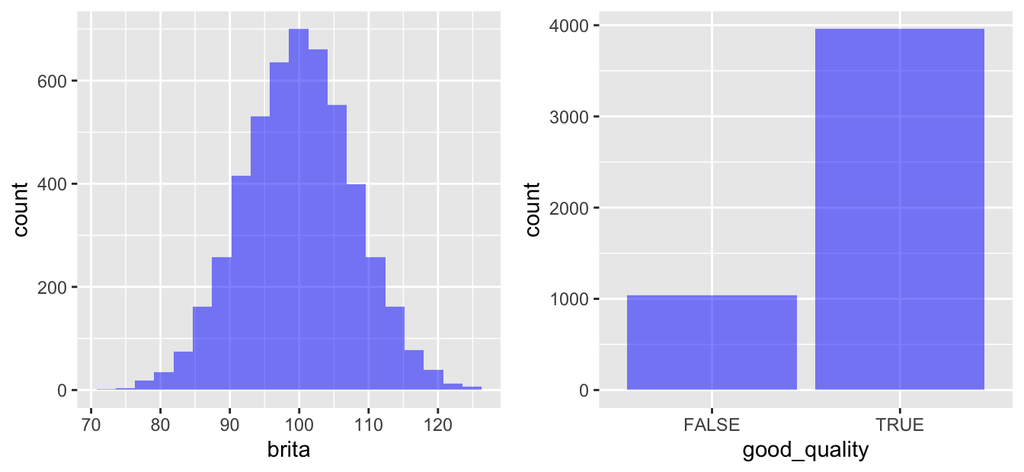

```r
plot(simdat, custom = FALSE)
```

```r
register("simdat")
```

In part (b) we want to determine the probability of finding 3 or more “good quality” filters out of a sample of 5. This means we should repeat the initial simulation from part (a) above, 5 times. To do this I selected “brita” as the *variable to re-simulate* in the *Repeat* tab, and selected the variable of interest “good_quality” in the *Output variable* box. In this example, I would like to determine the number of filters with good quality across 5 repetitions, so I selected *Simulation* in the *Group by* box and *sum* in the *Apply function* box. The result shows that the probability that at least 3 of 5 examined filters are good quality is 0.9348, which is also very similar to what I got above and in the second video of probability calculator (i.e., 0.933). By increasing the number of simulation runs, e.g., to 500,000, we could get even closer to the theoretical estimate.

```r
repdat <- repeater(
  simdat,
  nr = 5,
  vars = "brita",
  sum_vars = "good_quality",
  form = "good_quality_3 = good_quality_sum >= 3",
  seed = 1234
)
summary(repdat, dec = 4)
```

```
Repeated simulation
Simulations   : 5,000
Repetitions   : 5
Re-simulated  : brita
Group by      : Simulation
Function      : sum
Random  seed  : 1234
Simulated data: simdat
Repeat data   : repdat
Formulas      :
    good_quality_3 = good_quality_sum >= 3

Variables:
         variable n_obs   mean     sd min    p25 median    p75 max
 good_quality_sum 5,000 3.9546 0.9053   0 3.0000 4.0000 5.0000   5

Logicals:
               TRUE (nr)   TRUE (prop)
good_quality_3       4,674      0.9348
```

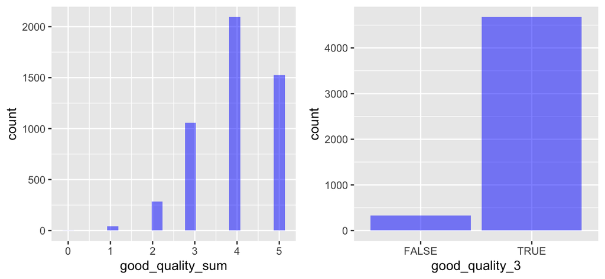

```r
plot(repdat, custom = FALSE)
```

```r
register("repdat")
```

To better understand the data generated in the repeated simulation set “Apply function” to None by removing all shown functions (i.e., click on the `x`). Also remove the formula or put a `#` in front of the formula so it will not be evaluated. Run the repeated simulation again and save the data as *repdat1*. In *Data > View* you will see there are 25,000 entries in this dataset (i.e., 5 repetitions of a simulation with 5,000 runs). I am going to reshape it into a $5,000 \times 5$ matrix in the *Data > Transform* tab by selecting “Spread column” as *Transformation type*. Select “.rep” as the *key* and “good_quality” as the *value*. In the first row of the reshaped dataset we can see that the first two filters are good quality. In the second row all 5 filters are good.

```r
repdat1 <- repeater(
  simdat,
  nr = 5,
  vars = "brita",
  sum_vars = "good_quality",
  seed = 1234,
  fun = "none"
)
summary(repdat1, dec = 3)
```

```
Repeated simulation
Simulations   : 5,000
Repetitions   : 5
Re-simulated  : brita
Group by      : Simulation
Function      : none
Random  seed  : 1234
Simulated data: simdat
Repeat data   : repdat1

Variables:
 variable  n_obs      mean        sd min       p25    median       p75   max
     .sim 25,000 2,500.500 1,443.405   1 1,250.750 2,500.500 3,750.250 5,000

Logicals:
             TRUE (nr)   TRUE (prop)
good_quality      19,773       0.791
```

```r
register("repdat1")
```

```r
## Spread columns
repdat1_spread <- spread(repdat1, .rep, good_quality)
## register the new dataset
register("repdat1_spread", "repdat1")
```

```r
## filter and sort the dataset
dtab(repdat1_spread, dec = 2, nr = 10) %>% render()
```

| .sim | 1 | 2 | 3 | 4 | 5 |
| --- | --- | --- | --- | --- | --- |
| 1 | True | True | False | False | False |
| 2 | True | True | True | True | True |
| 3 | True | True | True | True | True |
| 4 | False | True | True | True | True |
| 5 | True | True | False | True | True |
| 6 | True | True | True | False | False |
| 7 | True | False | False | True | True |
| 8 | True | True | True | True | False |
| 9 | True | True | True | False | False |
| 10 | True | False | True | True | False |

Now lets take another look at the `repdat` dataset we created earlier. You can see in the first row that the sum of `good_quality`, i.e., `good_quality_sum` created through repeated simulation is also equal to 2. In the second row we see that `good_quality_sum` is equal to 5, just as we see in the reshaped matrix above.

```r
## filter and sort the dataset
dtab(repdat, dec = 2, nr = 10) %>% render()
```

| .sim | good_quality_sum | good_quality_3 |
| --- | --- | --- |
| 1 | 2 | False |
| 2 | 5 | True |
| 3 | 5 | True |
| 4 | 4 | True |
| 5 | 4 | True |
| 6 | 3 | True |
| 7 | 3 | True |
| 8 | 4 | True |
| 9 | 3 | True |
| 10 | 3 | True |

Finally, let’s take another look at the dataset (*repdat*) in the *Data > View* tab. If I filter data by the criterion $good\_quality >= 3$, 4,674 entries will be selected, which is the same number I got for `good_quality_3` in the repeated simulation shown above.